Sequence Board Game

# The *Blind 4th* Analysis

How often does Yellow spoil the game? 300,000 simulations across 10 skill combinations. Exported April 3, 2026.

Avg Yellow Spoil Rate

3.0%

across all 10 combinations

Worst for Yellow

2.06%

Mid / Mid / Mid

Best for Yellow

4.92%

Nov / Nov / Nov

Skill Spread

2.9pp

between best & worst combos

### Yellow vs Real Win Rate by Combo

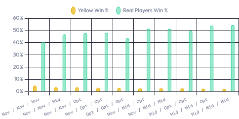

### Yellow Spoil Rate vs Average Skill Level

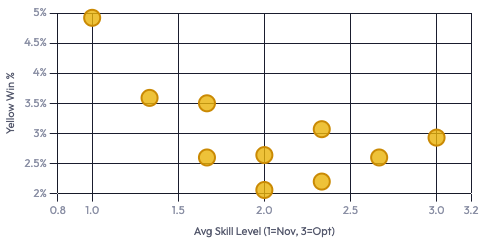

### Yellow Win % by # of Optimal Players

[figure not shown]

### Yellow Win % by # of Novice Players

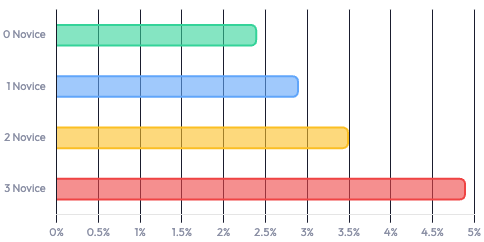

## Full Results

sorted by yellow %

| # | Skill Combo | Yellow Win % | Real Win % | Yellow Wins | Real Wins | Draws | Avg Skill |
| --- | --- | --- | --- | --- | --- | --- | --- |
| 1 | Nov / Nov / Nov ▲ worst for players | 4.92% | 40.74% | 1,476 | 12,222 | 16302 | 1.0 |
| 2 | Nov / Nov / Mid | 3.59% | 46.78% | 1,077 | 14,035 | 14888 | 1.3 |
| 3 | Nov / Nov / Opt | 3.5% | 48.05% | 1,049 | 14,414 | 14537 | 1.7 |
| 4 | Nov / Opt / Opt | 3.07% | 48.15% | 920 | 14,445 | 14635 | 2.3 |
| 5 | Opt / Opt / Opt | 2.93% | 43.56% | 878 | 13,068 | 16054 | 3.0 |
| 6 | Nov / Mid / Opt | 2.64% | 51.49% | 793 | 15,447 | 13760 | 2.0 |
| 7 | Nov / Mid / Mid | 2.6% | 51.42% | 781 | 15,425 | 13794 | 1.7 |
| 8 | Mid / Opt / Opt | 2.6% | 49.86% | 781 | 14,959 | 14260 | 2.7 |
| 9 | Mid / Mid / Opt | 2.2% | 54.07% | 661 | 16,221 | 13118 | 2.3 |
| 10 | Mid / Mid / Mid ▼ best for players | 2.06% | 54.42% | 618 | 16,326 | 13056 | 2.0 |

## Key Insights

auto-generated

#### The Headline

Across all skill combos, Yellow spoils the game an average of **3.0%** of the time. The worst case for real players is **Nov / Nov / Nov** (4.92%), while the best defense is **Mid / Mid / Mid** (2.06%).

#### Same-Skill Matchups

All Novice4.92% Yellow

All Middling2.06% Yellow

All Optimal2.93% Yellow

#### Mixed Skill Dynamics

Nov/Mid/Opt actual2.64%

Expected (avg of same-skill)3.3%

Difference-0.7pp

Mixed skill groups manage Yellow better than the average would predict.

#### Game Balance Assessment

Avg draws per combo14440

Total games simulated300,000

High draw rate suggests games often stall. Consider whether removing Jacks makes the game too slow.